# Journey Through Kerala

### Business Problem:

A traveler interested in visiting Kerala wants recommendations for the best tourist destinations based on: Budget constraints,limited travel time, travel preferences (nature, beaches, hill stations, adventure, honeymoon, family trip, etc.)The challenge is to help the traveler choose an optimized Kerala tour plan that minimizes cost and travel time while maximizing travel experience.

### Problem Statement

Analyze travelers budget, travel duration, and destination preferences to identify the most suitable places to visit in Kerala.Based on the analysis, recommend the Best tourist destinations, Budget-friendly travel plans, Time-efficient travel itineraries, Suitable accommodation and transport options, Personalized tour packages for travelers.

```python
# import packages
```

```python
import re
import requests
from bs4 import BeautifulSoup
import pandas as pd
import numpy as np
```

#### Webscraping Code

```python
tour_package=[]
Days=[]
Nights=[]
trip_duration=[]
discount_percentage=[]
Discount_price=[]
Actual_price=[]
Hotels_included_package=[]
Cities=[]
customizable=[]
activities=[]
for i in range(1,62):
    url='https://traveltriangle.com/tour-packages/Kerala'
    headers={
    "User-Agent": "Mozilla/5.0 (Windows NT 10.0; Win64; x64) AppleWebKit/537.36 (KHTML, like Gecko) Chrome/120 Safari/537.36"}
    page=requests.get(url,headers=headers)
    soup=BeautifulSoup(page.text)
    details=soup.find_all('div',class_="col-12 p8 pt0")
    for i in details:
        a=i.text
        result = " ".join(a.split())
        #print(result)
        b=re.findall(r"^(.*?)Please deselect",a)
        tour_package.append(b[0])
    for i in details:
        a=i.text
        #print(a)
        b=re.findall(r'(\d+)\sDays',a)
        Days.append(b[0])
    for i in details:
        a=i.text
        #print(a)
        b=re.findall(r'(\d+)\sNights',a)
        Nights.append(b[0])
    for i in details:
        a=i.text
        #print(a)
        b=re.findall(r'\d+\sDays\s&\s\d+\sNights',a)
        trip_duration.append(b[0])
    for i in details:
        a=i.text
        #print(a)
        b=re.findall(r'from:(\d+%)\sOffExact',a)
        discount_percentage.append(b[0])
    for i in details:
        a=i.text
        #print(a)
        b=re.findall(r'¹\s(.+)/-â',a)
        Discount_price.append(b[0])
    for i in details:
        a=i.text
        #print(a)
        b=re.findall(r'-â\x82¹\s(.+)/-Per',a)
        Actual_price.append(b[0])
    for i in details:
        a=i.text
        #print(a)
        b=re.findall(r'package:\s(.+)Cities',a)
        Hotels_included_package.append(b[0])
    for i in details:
        a=i.text
        #print(a)
        b=re.findall( r"Cities:\s*((?:[A-Za-z]+(?:\s[A-Za-z]+)?\s\(\d+D\))+)",a)
        Cities.append(b[0])
    for i in details:
        a=i.text
        #print(a)
        b=re.findall(r'Customizable',a)
        customizable.append("Yes" if b else "No")
    for i in details:
        a=i.text
        #print(a)
        b=re.findall(r"sharing(.*?)(?:Best sellersWaterfall|Budget)?(?:Hotel included in package:|Cities:)",a)
        text = " ".join(b)
        split_names = re.findall(r"[A-Z][a-z]+(?:\s[a-z]+)?(?:\s[A-Z][a-z]+)*",text)
        #print(split_names)
        activities.append(" ".join(split_names))
df=pd.DataFrame({"Package_name":tour_package,"Days":Days,"Nights":Nights,"Trip_duration":trip_duration,"Discount_Percent":discount_percentage,
                 "Discount_price":Discount_price,"Actual_price":Actual_price,"Hotels":Hotels_included_package,"Cities":Cities,"Customizable":customizable,"Activities_included":activities})
df
```

|  | Package_name | Days | Nights | Trip_duration | Discount_Percent | Discount_price | Actual_price | Hotels | Cities | Customizable | Activities_included |
| --- | --- | --- | --- | --- | --- | --- | --- | --- | --- | --- | --- |
| 0 | Alleppey-Munnar Kerala Weekend Tour | 4 | 3 | 4 Days & 3 Nights | 24% | 13,020 | 17,132 | 3 Star4 Star5 Star | Munnar (2D)Alleppey (2D) | Yes | Spice Plantations Hill station Houseboat Stay ... |
| 1 | Charismatic Kochi Tour Package | 4 | 3 | 4 Days & 3 Nights | 9% | 15,000 | 16,484 | 3 Star | Kochi (1D)Munnar (3D) | Yes | Waterfalls Adventure Nature Shopping Wildlife ... |
| 2 | Hills & Houseboat: Munnar and Alleppey Honeymo... | 6 | 5 | 6 Days & 5 Nights | 10% | 22,000 | 24,444 | 3 Star4 Star5 Star | Munnar (2D)Thekkady (1D)Alleppey (1D)Kochi (2D) | Yes | Periyar Wildlife Sanctuary Cruises Eravikulam ... |
| 3 | Vibrant Kochi Munnar Honeymoon Tour Package | 4 | 3 | 4 Days & 3 Nights | 10% | 14,571 | 16,190 | 3 Star5 Star | Cochin (1D)Munnar (3D) | Yes | Scenic views Adventure Tea gardens Hill statio... |
| 4 | Mesmerizing Getaway To Kochi | 2 | 1 | 2 Days & 1 Nights | 9% | 4,800 | 5,275 | 3 Star | Kochi (2D) | Yes | Scenerylandscape Sightseeing Leisure Time Natu... |
| ... | ... | ... | ... | ... | ... | ... | ... | ... | ... | ... | ... |
| 1215 | Ecstatic Athirapally Tour Package | 8 | 7 | 8 Days & 7 Nights | 9% | 28,123 | 30,904 | 3 Star | Athirapally (2D)Munnar (2D)Alleppey (1D)Kovala... | Yes | Athirapally waterfalls Nature Munnar Hill stat... |
| 1216 | Mesmerizing Kerala Holiday: Weekend in Munnar ... | 4 | 3 | 4 Days & 3 Nights | 29% | 13,167 | 18,434 | 3 Star4 Star5 Star | Munnar (2D)Thekkady (2D) | Yes | Hills Adventure Jungle Safari Nature Wildlife ... |
| 1217 | Captivating Thekkady Honeymoon Package | 5 | 4 | 5 Days & 4 Nights | 10% | 15,624 | 17,360 | 3 Star | Kumarakom (1D)Thekkady (1D)Munnar (3D) | Yes | Ideal for Couples Water Activities Adventure H... |
| 1218 | A Surreal Escape To Mesmerising Destinations | 4 | 3 | 4 Days & 3 Nights | 21% | 12,880 | 16,269 | 3 Star4 Star5 Star | Munnar (2D)Alleppey (2D) | Yes | Romantic Hill station Hills Cruises Waterfalls... |
| 1219 | Visit Kerala And See Astounding Places | 4 | 3 | 4 Days & 3 Nights | 11% | 11,760 | 13,213 | 3 Star4 Star5 Star | Munnar (1D)Thekkady (1D)Kochi (2D) | Yes | Natural Beauty Tea Garden Spice Garden Sightse... |

1220 rows × 11 columns

```python
df.to_csv('Project Dynamic Web Scrapping')
```

## EDA

#### Data Manipulation

```python
df.info()
```

```
<class 'pandas.DataFrame'>
RangeIndex: 1220 entries, 0 to 1219
Data columns (total 11 columns):
 #   Column               Non-Null Count  Dtype
---  ------               --------------  -----
 0   Package_name         1220 non-null   str
 1   Days                 1220 non-null   str
 2   Nights               1220 non-null   str
 3   Trip_duration        1220 non-null   str
 4   Discount_Percent     1220 non-null   str
 5   Discount_price       1220 non-null   str
 6   Actual_price         1220 non-null   str
 7   Hotels               1220 non-null   str
 8   Cities               1220 non-null   str
 9   Customizable         1220 non-null   str
 10  Activities_included  1220 non-null   str
dtypes: str(11)
memory usage: 105.0 KB
```

```python
df['Discount_price']=df['Discount_price'].str.replace(',','')
```

```python
df["Discount_price"]=df["Discount_price"].astype('int')
```

```python
df['Actual_price']=df['Actual_price'].str.replace(',','')
```

```python
df['Actual_price']=df['Actual_price'].astype('int')
```

```python
df['Discount_Percent']=df['Discount_Percent'].str.replace('%','')
```

```python
df['Discount_Percent']=df['Discount_Percent'].astype('int')
```

```python
df['Days']=df['Days'].astype('int')
```

```python
df['Nights']=df['Nights'].astype('int')
```

```python
df.info()
```

```
<class 'pandas.DataFrame'>
RangeIndex: 1220 entries, 0 to 1219
Data columns (total 11 columns):
 #   Column               Non-Null Count  Dtype
---  ------               --------------  -----
 0   Package_name         1220 non-null   str
 1   Days                 1220 non-null   int64
 2   Nights               1220 non-null   int64
 3   Trip_duration        1220 non-null   str
 4   Discount_Percent     1220 non-null   int64
 5   Discount_price       1220 non-null   int64
 6   Actual_price         1220 non-null   int64
 7   Hotels               1220 non-null   str
 8   Cities               1220 non-null   str
 9   Customizable         1220 non-null   str
 10  Activities_included  1220 non-null   str
dtypes: int64(5), str(6)
memory usage: 105.0 KB
```

```python
df.head(5)
```

|  | Package_name | Days | Nights | Trip_duration | Discount_Percent | Discount_price | Actual_price | Hotels | Cities | Customizable | Activities_included |
| --- | --- | --- | --- | --- | --- | --- | --- | --- | --- | --- | --- |
| 0 | Alleppey-Munnar Kerala Weekend Tour | 4 | 3 | 4 Days & 3 Nights | 24 | 13020 | 17132 | 3 Star4 Star5 Star | Munnar (2D)Alleppey (2D) | Yes | Spice Plantations Hill station Houseboat Stay ... |
| 1 | Charismatic Kochi Tour Package | 4 | 3 | 4 Days & 3 Nights | 9 | 15000 | 16484 | 3 Star | Kochi (1D)Munnar (3D) | Yes | Waterfalls Adventure Nature Shopping Wildlife ... |
| 2 | Hills & Houseboat: Munnar and Alleppey Honeymo... | 6 | 5 | 6 Days & 5 Nights | 10 | 22000 | 24444 | 3 Star4 Star5 Star | Munnar (2D)Thekkady (1D)Alleppey (1D)Kochi (2D) | Yes | Periyar Wildlife Sanctuary Cruises Eravikulam ... |
| 3 | Vibrant Kochi Munnar Honeymoon Tour Package | 4 | 3 | 4 Days & 3 Nights | 10 | 14571 | 16190 | 3 Star5 Star | Cochin (1D)Munnar (3D) | Yes | Scenic views Adventure Tea gardens Hill statio... |
| 4 | Mesmerizing Getaway To Kochi | 2 | 1 | 2 Days & 1 Nights | 9 | 4800 | 5275 | 3 Star | Kochi (2D) | Yes | Scenerylandscape Sightseeing Leisure Time Natu... |

#### 1. Find all Kerala tour packages that offer a discount greater than 25%.

```python
df[df['Discount_Percent']>25]
```

|  | Package_name | Days | Nights | Trip_duration | Discount_Percent | Discount_price | Actual_price | Hotels | Cities | Customizable | Activities_included |
| --- | --- | --- | --- | --- | --- | --- | --- | --- | --- | --- | --- |
| 7 | Best Selling Kerala Honeymoon Tour Package | 5 | 4 | 5 Days & 4 Nights | 28 | 19040 | 26478 | 3 Star4 Star5 Star | Munnar (2D)Thekkady (1D)Alleppey (2D) | Yes | Houseboat Stay Adventure Jeep Safari Hill stat... |
| 16 | Mesmerizing Kerala Holiday: Weekend in Munnar ... | 4 | 3 | 4 Days & 3 Nights | 29 | 13167 | 18434 | 3 Star4 Star5 Star | Munnar (2D)Thekkady (2D) | Yes | Hills Adventure Jungle Safari Nature Wildlife ... |
| 27 | Best Selling Kerala Honeymoon Tour Package | 5 | 4 | 5 Days & 4 Nights | 28 | 19040 | 26478 | 3 Star4 Star5 Star | Munnar (2D)Thekkady (1D)Alleppey (2D) | Yes | Houseboat Stay Adventure Jeep Safari Hill stat... |
| 36 | Mesmerizing Kerala Holiday: Weekend in Munnar ... | 4 | 3 | 4 Days & 3 Nights | 29 | 13167 | 18434 | 3 Star4 Star5 Star | Munnar (2D)Thekkady (2D) | Yes | Hills Adventure Jungle Safari Nature Wildlife ... |
| 47 | Best Selling Kerala Honeymoon Tour Package | 5 | 4 | 5 Days & 4 Nights | 28 | 19040 | 26478 | 3 Star4 Star5 Star | Munnar (2D)Thekkady (1D)Alleppey (2D) | Yes | Houseboat Stay Adventure Jeep Safari Hill stat... |
| ... | ... | ... | ... | ... | ... | ... | ... | ... | ... | ... | ... |
| 1176 | Mesmerizing Kerala Holiday: Weekend in Munnar ... | 4 | 3 | 4 Days & 3 Nights | 29 | 13167 | 18434 | 3 Star4 Star5 Star | Munnar (2D)Thekkady (2D) | Yes | Hills Adventure Jungle Safari Nature Wildlife ... |
| 1187 | Best Selling Kerala Honeymoon Tour Package | 5 | 4 | 5 Days & 4 Nights | 28 | 19040 | 26478 | 3 Star4 Star5 Star | Munnar (2D)Thekkady (1D)Alleppey (2D) | Yes | Houseboat Stay Adventure Jeep Safari Hill stat... |
| 1196 | Mesmerizing Kerala Holiday: Weekend in Munnar ... | 4 | 3 | 4 Days & 3 Nights | 29 | 13167 | 18434 | 3 Star4 Star5 Star | Munnar (2D)Thekkady (2D) | Yes | Hills Adventure Jungle Safari Nature Wildlife ... |
| 1207 | Best Selling Kerala Honeymoon Tour Package | 5 | 4 | 5 Days & 4 Nights | 28 | 19040 | 26478 | 3 Star4 Star5 Star | Munnar (2D)Thekkady (1D)Alleppey (2D) | Yes | Houseboat Stay Adventure Jeep Safari Hill stat... |
| 1216 | Mesmerizing Kerala Holiday: Weekend in Munnar ... | 4 | 3 | 4 Days & 3 Nights | 29 | 13167 | 18434 | 3 Star4 Star5 Star | Munnar (2D)Thekkady (2D) | Yes | Hills Adventure Jungle Safari Nature Wildlife ... |

122 rows × 11 columns

#### 2. Display all tour packages that include 5-star hotels.

```python
df[df['Hotels'].str.contains('5 Star')]
```

|  | Package_name | Days | Nights | Trip_duration | Discount_Percent | Discount_price | Actual_price | Hotels | Cities | Customizable | Activities_included |
| --- | --- | --- | --- | --- | --- | --- | --- | --- | --- | --- | --- |
| 0 | Alleppey-Munnar Kerala Weekend Tour | 4 | 3 | 4 Days & 3 Nights | 24 | 13020 | 17132 | 3 Star4 Star5 Star | Munnar (2D)Alleppey (2D) | Yes | Spice Plantations Hill station Houseboat Stay ... |
| 2 | Hills & Houseboat: Munnar and Alleppey Honeymo... | 6 | 5 | 6 Days & 5 Nights | 10 | 22000 | 24444 | 3 Star4 Star5 Star | Munnar (2D)Thekkady (1D)Alleppey (1D)Kochi (2D) | Yes | Periyar Wildlife Sanctuary Cruises Eravikulam ... |
| 3 | Vibrant Kochi Munnar Honeymoon Tour Package | 4 | 3 | 4 Days & 3 Nights | 10 | 14571 | 16190 | 3 Star5 Star | Cochin (1D)Munnar (3D) | Yes | Scenic views Adventure Tea gardens Hill statio... |
| 7 | Best Selling Kerala Honeymoon Tour Package | 5 | 4 | 5 Days & 4 Nights | 28 | 19040 | 26478 | 3 Star4 Star5 Star | Munnar (2D)Thekkady (1D)Alleppey (2D) | Yes | Houseboat Stay Adventure Jeep Safari Hill stat... |
| 9 | Best Selling Kerala Houseboat & Jungle Safari ... | 5 | 4 | 5 Days & 4 Nights | 19 | 20048 | 24604 | 3 Star4 Star5 Star | Munnar (2D)Thekkady (1D)Alleppey (2D) | Yes | Best Selling Private Cab Wildlife safari Backw... |
| ... | ... | ... | ... | ... | ... | ... | ... | ... | ... | ... | ... |
| 1213 | Exploring Godâs Own Country, Kerala | 3 | 2 | 3 Days & 2 Nights | 10 | 9092 | 10102 | 3 Star4 Star5 Star | Munnar (1D)Alleppey (2D) | Yes | Adventure Sightseeing Nature Hill station Hous... |
| 1214 | Reasonable Munnar Thekkady Alleppey Honeymoon ... | 4 | 3 | 4 Days & 3 Nights | 12 | 14000 | 15909 | 3 Star4 Star5 Star | Munnar (1D)Thekkady (1D)Alleppey (2D) | Yes | Cruises Waterfalls Nature Jungle Safari Romant... |
| 1216 | Mesmerizing Kerala Holiday: Weekend in Munnar ... | 4 | 3 | 4 Days & 3 Nights | 29 | 13167 | 18434 | 3 Star4 Star5 Star | Munnar (2D)Thekkady (2D) | Yes | Hills Adventure Jungle Safari Nature Wildlife ... |
| 1218 | A Surreal Escape To Mesmerising Destinations | 4 | 3 | 4 Days & 3 Nights | 21 | 12880 | 16269 | 3 Star4 Star5 Star | Munnar (2D)Alleppey (2D) | Yes | Romantic Hill station Hills Cruises Waterfalls... |
| 1219 | Visit Kerala And See Astounding Places | 4 | 3 | 4 Days & 3 Nights | 11 | 11760 | 13213 | 3 Star4 Star5 Star | Munnar (1D)Thekkady (1D)Kochi (2D) | Yes | Natural Beauty Tea Garden Spice Garden Sightse... |

671 rows × 11 columns

#### 3. Display all tour packages where the actual price is greater than ₹30,000.

```python
df[df['Actual_price']>30000]
```

|  | Package_name | Days | Nights | Trip_duration | Discount_Percent | Discount_price | Actual_price | Hotels | Cities | Customizable | Activities_included |
| --- | --- | --- | --- | --- | --- | --- | --- | --- | --- | --- | --- |
| 15 | Ecstatic Athirapally Tour Package | 8 | 7 | 8 Days & 7 Nights | 9 | 28123 | 30904 | 3 Star | Athirapally (2D)Munnar (2D)Alleppey (1D)Kovala... | Yes | Athirapally waterfalls Nature Munnar Hill stat... |
| 35 | Ecstatic Athirapally Tour Package | 8 | 7 | 8 Days & 7 Nights | 9 | 28123 | 30904 | 3 Star | Athirapally (2D)Munnar (2D)Alleppey (1D)Kovala... | Yes | Athirapally waterfalls Nature Munnar Hill stat... |
| 55 | Ecstatic Athirapally Tour Package | 8 | 7 | 8 Days & 7 Nights | 9 | 28123 | 30904 | 3 Star | Athirapally (2D)Munnar (2D)Alleppey (1D)Kovala... | Yes | Athirapally waterfalls Nature Munnar Hill stat... |
| 75 | Ecstatic Athirapally Tour Package | 8 | 7 | 8 Days & 7 Nights | 9 | 28123 | 30904 | 3 Star | Athirapally (2D)Munnar (2D)Alleppey (1D)Kovala... | Yes | Athirapally waterfalls Nature Munnar Hill stat... |
| 95 | Ecstatic Athirapally Tour Package | 8 | 7 | 8 Days & 7 Nights | 9 | 28123 | 30904 | 3 Star | Athirapally (2D)Munnar (2D)Alleppey (1D)Kovala... | Yes | Athirapally waterfalls Nature Munnar Hill stat... |
| ... | ... | ... | ... | ... | ... | ... | ... | ... | ... | ... | ... |
| 1135 | Ecstatic Athirapally Tour Package | 8 | 7 | 8 Days & 7 Nights | 9 | 28123 | 30904 | 3 Star | Athirapally (2D)Munnar (2D)Alleppey (1D)Kovala... | Yes | Athirapally waterfalls Nature Munnar Hill stat... |
| 1155 | Ecstatic Athirapally Tour Package | 8 | 7 | 8 Days & 7 Nights | 9 | 28123 | 30904 | 3 Star | Athirapally (2D)Munnar (2D)Alleppey (1D)Kovala... | Yes | Athirapally waterfalls Nature Munnar Hill stat... |
| 1175 | Ecstatic Athirapally Tour Package | 8 | 7 | 8 Days & 7 Nights | 9 | 28123 | 30904 | 3 Star | Athirapally (2D)Munnar (2D)Alleppey (1D)Kovala... | Yes | Athirapally waterfalls Nature Munnar Hill stat... |
| 1195 | Ecstatic Athirapally Tour Package | 8 | 7 | 8 Days & 7 Nights | 9 | 28123 | 30904 | 3 Star | Athirapally (2D)Munnar (2D)Alleppey (1D)Kovala... | Yes | Athirapally waterfalls Nature Munnar Hill stat... |
| 1215 | Ecstatic Athirapally Tour Package | 8 | 7 | 8 Days & 7 Nights | 9 | 28123 | 30904 | 3 Star | Athirapally (2D)Munnar (2D)Alleppey (1D)Kovala... | Yes | Athirapally waterfalls Nature Munnar Hill stat... |

61 rows × 11 columns

#### 4. Display 1 to 100 rows

```python
df.loc[1:100]
```

|  | Package_name | Days | Nights | Trip_duration | Discount_Percent | Discount_price | Actual_price | Hotels | Cities | Customizable | Activities_included |
| --- | --- | --- | --- | --- | --- | --- | --- | --- | --- | --- | --- |
| 1 | Charismatic Kochi Tour Package | 4 | 3 | 4 Days & 3 Nights | 9 | 15000 | 16484 | 3 Star | Kochi (1D)Munnar (3D) | Yes | Waterfalls Adventure Nature Shopping Wildlife ... |
| 2 | Hills & Houseboat: Munnar and Alleppey Honeymo... | 6 | 5 | 6 Days & 5 Nights | 10 | 22000 | 24444 | 3 Star4 Star5 Star | Munnar (2D)Thekkady (1D)Alleppey (1D)Kochi (2D) | Yes | Periyar Wildlife Sanctuary Cruises Eravikulam ... |
| 3 | Vibrant Kochi Munnar Honeymoon Tour Package | 4 | 3 | 4 Days & 3 Nights | 10 | 14571 | 16190 | 3 Star5 Star | Cochin (1D)Munnar (3D) | Yes | Scenic views Adventure Tea gardens Hill statio... |
| 4 | Mesmerizing Getaway To Kochi | 2 | 1 | 2 Days & 1 Nights | 9 | 4800 | 5275 | 3 Star | Kochi (2D) | Yes | Scenerylandscape Sightseeing Leisure Time Natu... |
| 5 | Kerala Wayanad Weekend Holiday | 3 | 2 | 3 Days & 2 Nights | 5 | 8500 | 8947 | 3 Star4 Star | Wayanad (3D) | Yes | Nature Waterfall Hills Weekend Getaway Hill st... |
| ... | ... | ... | ... | ... | ... | ... | ... | ... | ... | ... | ... |
| 96 | Mesmerizing Kerala Holiday: Weekend in Munnar ... | 4 | 3 | 4 Days & 3 Nights | 29 | 13167 | 18434 | 3 Star4 Star5 Star | Munnar (2D)Thekkady (2D) | Yes | Hills Adventure Jungle Safari Nature Wildlife ... |
| 97 | Captivating Thekkady Honeymoon Package | 5 | 4 | 5 Days & 4 Nights | 10 | 15624 | 17360 | 3 Star | Kumarakom (1D)Thekkady (1D)Munnar (3D) | Yes | Ideal for Couples Water Activities Adventure H... |
| 98 | A Surreal Escape To Mesmerising Destinations | 4 | 3 | 4 Days & 3 Nights | 21 | 12880 | 16269 | 3 Star4 Star5 Star | Munnar (2D)Alleppey (2D) | Yes | Romantic Hill station Hills Cruises Waterfalls... |
| 99 | Visit Kerala And See Astounding Places | 4 | 3 | 4 Days & 3 Nights | 11 | 11760 | 13213 | 3 Star4 Star5 Star | Munnar (1D)Thekkady (1D)Kochi (2D) | Yes | Natural Beauty Tea Garden Spice Garden Sightse... |
| 100 | Alleppey-Munnar Kerala Weekend Tour | 4 | 3 | 4 Days & 3 Nights | 24 | 13020 | 17132 | 3 Star4 Star5 Star | Munnar (2D)Alleppey (2D) | Yes | Spice Plantations Hill station Houseboat Stay ... |

100 rows × 11 columns

#### 5. Display first 50 rows and first 5 columns using iloc

```python
df.iloc[:50,0:5]
```

|  | Package_name | Days | Nights | Trip_duration | Discount_Percent |
| --- | --- | --- | --- | --- | --- |
| 0 | Alleppey-Munnar Kerala Weekend Tour | 4 | 3 | 4 Days & 3 Nights | 24 |
| 1 | Charismatic Kochi Tour Package | 4 | 3 | 4 Days & 3 Nights | 9 |
| 2 | Hills & Houseboat: Munnar and Alleppey Honeymo... | 6 | 5 | 6 Days & 5 Nights | 10 |
| 3 | Vibrant Kochi Munnar Honeymoon Tour Package | 4 | 3 | 4 Days & 3 Nights | 10 |
| 4 | Mesmerizing Getaway To Kochi | 2 | 1 | 2 Days & 1 Nights | 9 |
| 5 | Kerala Wayanad Weekend Holiday | 3 | 2 | 3 Days & 2 Nights | 5 |
| 6 | Trip To Mesmerising Munnar | 4 | 3 | 4 Days & 3 Nights | 9 |
| 7 | Best Selling Kerala Honeymoon Tour Package | 5 | 4 | 5 Days & 4 Nights | 28 |
| 8 | Catch The Beauty Of The Setting Sun In Alleppey | 2 | 1 | 2 Days & 1 Nights | 9 |
| 9 | Best Selling Kerala Houseboat & Jungle Safari ... | 5 | 4 | 5 Days & 4 Nights | 19 |
| 10 | Charming Alleppey Honeymoon Package | 3 | 2 | 3 Days & 2 Nights | 9 |
| 11 | A Blissful Tour In Munnar | 3 | 2 | 3 Days & 2 Nights | 9 |
| 12 | Top 5 Nights 6 Days Kerala Family Tour Package... | 6 | 5 | 6 Days & 5 Nights | 18 |
| 13 | Exploring Godâs Own Country, Kerala | 3 | 2 | 3 Days & 2 Nights | 10 |
| 14 | Reasonable Munnar Thekkady Alleppey Honeymoon ... | 4 | 3 | 4 Days & 3 Nights | 12 |
| 15 | Ecstatic Athirapally Tour Package | 8 | 7 | 8 Days & 7 Nights | 9 |
| 16 | Mesmerizing Kerala Holiday: Weekend in Munnar ... | 4 | 3 | 4 Days & 3 Nights | 29 |
| 17 | Captivating Thekkady Honeymoon Package | 5 | 4 | 5 Days & 4 Nights | 10 |
| 18 | A Surreal Escape To Mesmerising Destinations | 4 | 3 | 4 Days & 3 Nights | 21 |
| 19 | Visit Kerala And See Astounding Places | 4 | 3 | 4 Days & 3 Nights | 11 |
| 20 | Alleppey-Munnar Kerala Weekend Tour | 4 | 3 | 4 Days & 3 Nights | 24 |
| 21 | Charismatic Kochi Tour Package | 4 | 3 | 4 Days & 3 Nights | 9 |
| 22 | Hills & Houseboat: Munnar and Alleppey Honeymo... | 6 | 5 | 6 Days & 5 Nights | 10 |
| 23 | Vibrant Kochi Munnar Honeymoon Tour Package | 4 | 3 | 4 Days & 3 Nights | 10 |
| 24 | Mesmerizing Getaway To Kochi | 2 | 1 | 2 Days & 1 Nights | 9 |
| 25 | Kerala Wayanad Weekend Holiday | 3 | 2 | 3 Days & 2 Nights | 5 |
| 26 | Trip To Mesmerising Munnar | 4 | 3 | 4 Days & 3 Nights | 9 |
| 27 | Best Selling Kerala Honeymoon Tour Package | 5 | 4 | 5 Days & 4 Nights | 28 |
| 28 | Catch The Beauty Of The Setting Sun In Alleppey | 2 | 1 | 2 Days & 1 Nights | 9 |
| 29 | Best Selling Kerala Houseboat & Jungle Safari ... | 5 | 4 | 5 Days & 4 Nights | 19 |
| 30 | Charming Alleppey Honeymoon Package | 3 | 2 | 3 Days & 2 Nights | 9 |
| 31 | A Blissful Tour In Munnar | 3 | 2 | 3 Days & 2 Nights | 9 |
| 32 | Top 5 Nights 6 Days Kerala Family Tour Package... | 6 | 5 | 6 Days & 5 Nights | 18 |
| 33 | Exploring Godâs Own Country, Kerala | 3 | 2 | 3 Days & 2 Nights | 10 |
| 34 | Reasonable Munnar Thekkady Alleppey Honeymoon ... | 4 | 3 | 4 Days & 3 Nights | 12 |
| 35 | Ecstatic Athirapally Tour Package | 8 | 7 | 8 Days & 7 Nights | 9 |
| 36 | Mesmerizing Kerala Holiday: Weekend in Munnar ... | 4 | 3 | 4 Days & 3 Nights | 29 |
| 37 | Captivating Thekkady Honeymoon Package | 5 | 4 | 5 Days & 4 Nights | 10 |
| 38 | A Surreal Escape To Mesmerising Destinations | 4 | 3 | 4 Days & 3 Nights | 21 |
| 39 | Visit Kerala And See Astounding Places | 4 | 3 | 4 Days & 3 Nights | 11 |
| 40 | Alleppey-Munnar Kerala Weekend Tour | 4 | 3 | 4 Days & 3 Nights | 24 |
| 41 | Charismatic Kochi Tour Package | 4 | 3 | 4 Days & 3 Nights | 9 |
| 42 | Hills & Houseboat: Munnar and Alleppey Honeymo... | 6 | 5 | 6 Days & 5 Nights | 10 |
| 43 | Vibrant Kochi Munnar Honeymoon Tour Package | 4 | 3 | 4 Days & 3 Nights | 10 |
| 44 | Mesmerizing Getaway To Kochi | 2 | 1 | 2 Days & 1 Nights | 9 |
| 45 | Kerala Wayanad Weekend Holiday | 3 | 2 | 3 Days & 2 Nights | 5 |
| 46 | Trip To Mesmerising Munnar | 4 | 3 | 4 Days & 3 Nights | 9 |
| 47 | Best Selling Kerala Honeymoon Tour Package | 5 | 4 | 5 Days & 4 Nights | 28 |
| 48 | Catch The Beauty Of The Setting Sun In Alleppey | 2 | 1 | 2 Days & 1 Nights | 9 |
| 49 | Best Selling Kerala Houseboat & Jungle Safari ... | 5 | 4 | 5 Days & 4 Nights | 19 |

#### 6. Display first 50 rows and Columns from Days to Actual_price using loc

```python
df.loc[:50,'Days':'Actual_price']
```

|  | Days | Nights | Trip_duration | Discount_Percent | Discount_price | Actual_price |
| --- | --- | --- | --- | --- | --- | --- |
| 0 | 4 | 3 | 4 Days & 3 Nights | 24 | 13020 | 17132 |
| 1 | 4 | 3 | 4 Days & 3 Nights | 9 | 15000 | 16484 |
| 2 | 6 | 5 | 6 Days & 5 Nights | 10 | 22000 | 24444 |
| 3 | 4 | 3 | 4 Days & 3 Nights | 10 | 14571 | 16190 |
| 4 | 2 | 1 | 2 Days & 1 Nights | 9 | 4800 | 5275 |
| 5 | 3 | 2 | 3 Days & 2 Nights | 5 | 8500 | 8947 |
| 6 | 4 | 3 | 4 Days & 3 Nights | 9 | 15000 | 16484 |
| 7 | 5 | 4 | 5 Days & 4 Nights | 28 | 19040 | 26478 |
| 8 | 2 | 1 | 2 Days & 1 Nights | 9 | 5000 | 5495 |
| 9 | 5 | 4 | 5 Days & 4 Nights | 19 | 20048 | 24604 |
| 10 | 3 | 2 | 3 Days & 2 Nights | 9 | 7840 | 8615 |
| 11 | 3 | 2 | 3 Days & 2 Nights | 9 | 6000 | 6593 |
| 12 | 6 | 5 | 6 Days & 5 Nights | 18 | 24279 | 29674 |
| 13 | 3 | 2 | 3 Days & 2 Nights | 10 | 9092 | 10102 |
| 14 | 4 | 3 | 4 Days & 3 Nights | 12 | 14000 | 15909 |
| 15 | 8 | 7 | 8 Days & 7 Nights | 9 | 28123 | 30904 |
| 16 | 4 | 3 | 4 Days & 3 Nights | 29 | 13167 | 18434 |
| 17 | 5 | 4 | 5 Days & 4 Nights | 10 | 15624 | 17360 |
| 18 | 4 | 3 | 4 Days & 3 Nights | 21 | 12880 | 16269 |
| 19 | 4 | 3 | 4 Days & 3 Nights | 11 | 11760 | 13213 |
| 20 | 4 | 3 | 4 Days & 3 Nights | 24 | 13020 | 17132 |
| 21 | 4 | 3 | 4 Days & 3 Nights | 9 | 15000 | 16484 |
| 22 | 6 | 5 | 6 Days & 5 Nights | 10 | 22000 | 24444 |
| 23 | 4 | 3 | 4 Days & 3 Nights | 10 | 14571 | 16190 |
| 24 | 2 | 1 | 2 Days & 1 Nights | 9 | 4800 | 5275 |
| 25 | 3 | 2 | 3 Days & 2 Nights | 5 | 8500 | 8947 |
| 26 | 4 | 3 | 4 Days & 3 Nights | 9 | 15000 | 16484 |
| 27 | 5 | 4 | 5 Days & 4 Nights | 28 | 19040 | 26478 |
| 28 | 2 | 1 | 2 Days & 1 Nights | 9 | 5000 | 5495 |
| 29 | 5 | 4 | 5 Days & 4 Nights | 19 | 20048 | 24604 |
| 30 | 3 | 2 | 3 Days & 2 Nights | 9 | 7840 | 8615 |
| 31 | 3 | 2 | 3 Days & 2 Nights | 9 | 6000 | 6593 |
| 32 | 6 | 5 | 6 Days & 5 Nights | 18 | 24279 | 29674 |
| 33 | 3 | 2 | 3 Days & 2 Nights | 10 | 9092 | 10102 |
| 34 | 4 | 3 | 4 Days & 3 Nights | 12 | 14000 | 15909 |
| 35 | 8 | 7 | 8 Days & 7 Nights | 9 | 28123 | 30904 |
| 36 | 4 | 3 | 4 Days & 3 Nights | 29 | 13167 | 18434 |
| 37 | 5 | 4 | 5 Days & 4 Nights | 10 | 15624 | 17360 |
| 38 | 4 | 3 | 4 Days & 3 Nights | 21 | 12880 | 16269 |
| 39 | 4 | 3 | 4 Days & 3 Nights | 11 | 11760 | 13213 |
| 40 | 4 | 3 | 4 Days & 3 Nights | 24 | 13020 | 17132 |
| 41 | 4 | 3 | 4 Days & 3 Nights | 9 | 15000 | 16484 |
| 42 | 6 | 5 | 6 Days & 5 Nights | 10 | 22000 | 24444 |
| 43 | 4 | 3 | 4 Days & 3 Nights | 10 | 14571 | 16190 |
| 44 | 2 | 1 | 2 Days & 1 Nights | 9 | 4800 | 5275 |
| 45 | 3 | 2 | 3 Days & 2 Nights | 5 | 8500 | 8947 |
| 46 | 4 | 3 | 4 Days & 3 Nights | 9 | 15000 | 16484 |
| 47 | 5 | 4 | 5 Days & 4 Nights | 28 | 19040 | 26478 |
| 48 | 2 | 1 | 2 Days & 1 Nights | 9 | 5000 | 5495 |
| 49 | 5 | 4 | 5 Days & 4 Nights | 19 | 20048 | 24604 |
| 50 | 3 | 2 | 3 Days & 2 Nights | 9 | 7840 | 8615 |

#### 7. Display package name at 20th row using at

```python
df.at[20,'Package_name']
```

```
'Alleppey-Munnar Kerala Weekend Tour '
```

```python
df.iat[1200,0]
```

```
'Alleppey-Munnar Kerala Weekend Tour '
```

#### 9. Display 388 row and 5 column value using iat

```python
df.iat[388,5]
```

```
np.int64(5000)
```

### Data Visualization

#### Univariate

```python
import matplotlib.pyplot as plt
import seaborn as sns
```

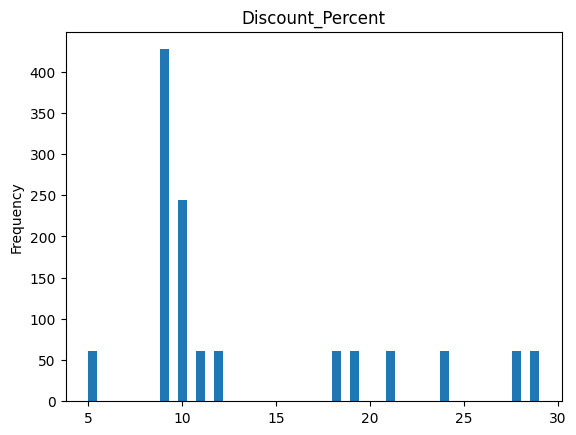

```python
df['Discount_Percent'].plot(kind='hist',bins=50,title="Discount_Percent");
```

There is a high frequency of the 9% discount option.

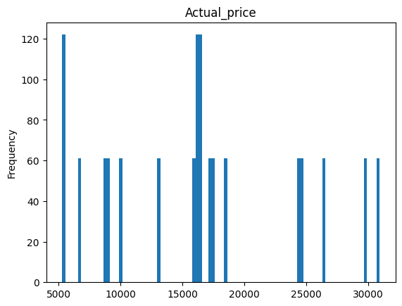

```python
df['Actual_price'].plot(kind='hist',bins=100,title="Actual_price");
```

```python
df
```

|  | Package_name | Days | Nights | Trip_duration | Discount_Percent | Discount_price | Actual_price | Hotels | Cities | Customizable | Activities_included |
| --- | --- | --- | --- | --- | --- | --- | --- | --- | --- | --- | --- |
| 0 | Alleppey-Munnar Kerala Weekend Tour | 4 | 3 | 4 Days & 3 Nights | 24 | 13020 | 17132 | 3 Star4 Star5 Star | Munnar (2D)Alleppey (2D) | Yes | Spice Plantations Hill station Houseboat Stay ... |
| 1 | Charismatic Kochi Tour Package | 4 | 3 | 4 Days & 3 Nights | 9 | 15000 | 16484 | 3 Star | Kochi (1D)Munnar (3D) | Yes | Waterfalls Adventure Nature Shopping Wildlife ... |
| 2 | Hills & Houseboat: Munnar and Alleppey Honeymo... | 6 | 5 | 6 Days & 5 Nights | 10 | 22000 | 24444 | 3 Star4 Star5 Star | Munnar (2D)Thekkady (1D)Alleppey (1D)Kochi (2D) | Yes | Periyar Wildlife Sanctuary Cruises Eravikulam ... |
| 3 | Vibrant Kochi Munnar Honeymoon Tour Package | 4 | 3 | 4 Days & 3 Nights | 10 | 14571 | 16190 | 3 Star5 Star | Cochin (1D)Munnar (3D) | Yes | Scenic views Adventure Tea gardens Hill statio... |
| 4 | Mesmerizing Getaway To Kochi | 2 | 1 | 2 Days & 1 Nights | 9 | 4800 | 5275 | 3 Star | Kochi (2D) | Yes | Scenerylandscape Sightseeing Leisure Time Natu... |
| ... | ... | ... | ... | ... | ... | ... | ... | ... | ... | ... | ... |
| 1215 | Ecstatic Athirapally Tour Package | 8 | 7 | 8 Days & 7 Nights | 9 | 28123 | 30904 | 3 Star | Athirapally (2D)Munnar (2D)Alleppey (1D)Kovala... | Yes | Athirapally waterfalls Nature Munnar Hill stat... |
| 1216 | Mesmerizing Kerala Holiday: Weekend in Munnar ... | 4 | 3 | 4 Days & 3 Nights | 29 | 13167 | 18434 | 3 Star4 Star5 Star | Munnar (2D)Thekkady (2D) | Yes | Hills Adventure Jungle Safari Nature Wildlife ... |
| 1217 | Captivating Thekkady Honeymoon Package | 5 | 4 | 5 Days & 4 Nights | 10 | 15624 | 17360 | 3 Star | Kumarakom (1D)Thekkady (1D)Munnar (3D) | Yes | Ideal for Couples Water Activities Adventure H... |
| 1218 | A Surreal Escape To Mesmerising Destinations | 4 | 3 | 4 Days & 3 Nights | 21 | 12880 | 16269 | 3 Star4 Star5 Star | Munnar (2D)Alleppey (2D) | Yes | Romantic Hill station Hills Cruises Waterfalls... |
| 1219 | Visit Kerala And See Astounding Places | 4 | 3 | 4 Days & 3 Nights | 11 | 11760 | 13213 | 3 Star4 Star5 Star | Munnar (1D)Thekkady (1D)Kochi (2D) | Yes | Natural Beauty Tea Garden Spice Garden Sightse... |

1220 rows × 11 columns

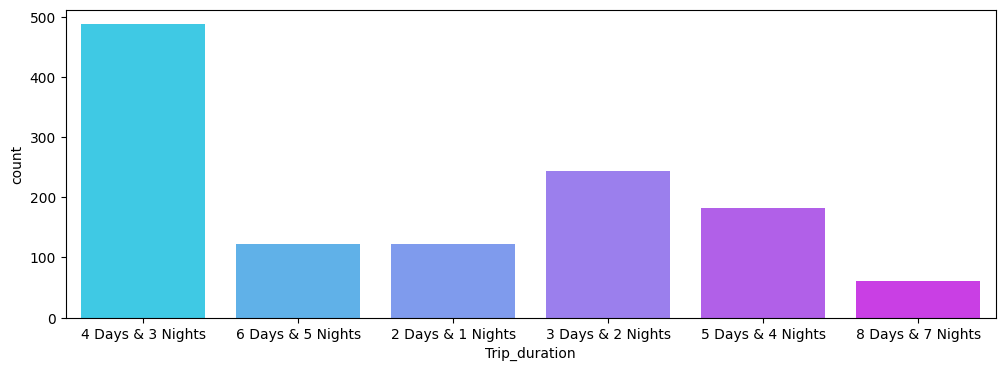

```python
plt.figure(figsize=(12,4))
sns.countplot(data=df,x='Trip_duration',palette='cool')
```

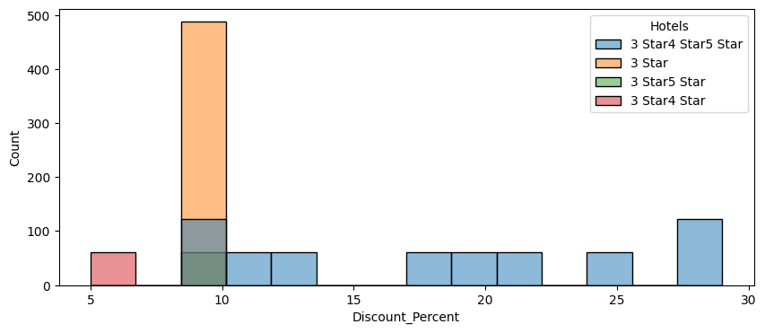

```python
plt.figure(figsize=(10,4))
sns.histplot(data=df,x='Discount_Percent',hue='Hotels')
```

[figure not shown]

```python
plt.figure(figsize=(76,30))
sns.countplot(data=df,x='Package_name',hue='Discount_Percent')
```

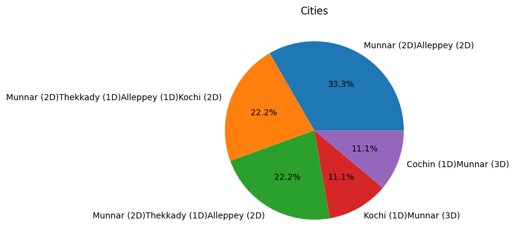

```python
df['Cities'].value_counts().nlargest().plot(kind='pie',autopct='%1.1f%%',title='Cities');
```

Most people choose to visit Munnar and Alleppey

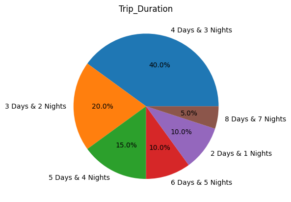

```python
df['Trip_duration'].value_counts().plot(kind='pie',autopct='%1.1f%%',title='Trip_Duration');
```

Most people choose a trip duration of 4 days and 3 nights, while fewer people choose 8 days and 7 nights.

#### Bivariate

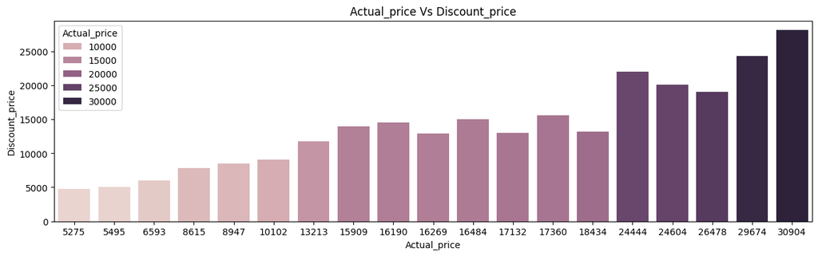

```python
plt.figure(figsize=(15,4))
sns.barplot(data=df,x='Actual_price',y='Discount_price',hue='Actual_price')
plt.title(label='Actual_price Vs Discount_price');
```

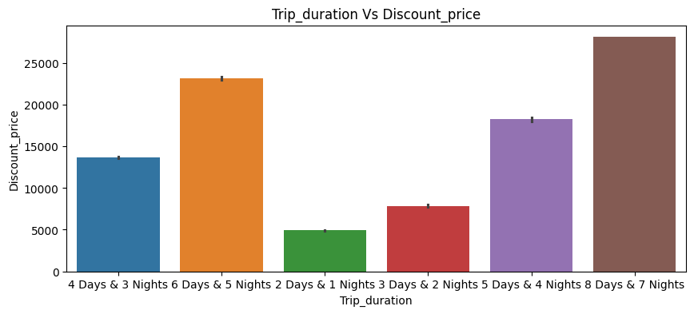

```python
plt.figure(figsize=(10,4))
sns.barplot(data=df,x='Trip_duration',y='Discount_price',hue='Trip_duration')
plt.title(label="Trip_duration Vs Discount_price");
```

The actual price depends on the number of days and nights; fewer days result in a lower actual price.

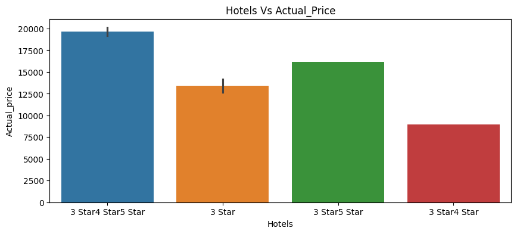

```python
plt.figure(figsize=(10,4))
sns.barplot(data=df,x='Hotels',y='Actual_price',hue='Hotels')
plt.title(label="Hotels Vs Actual_Price");
```

Hotel pricing depends on the package, especially the number of days and nights. Some packages include 3-star hotels, while others may include 3-star, 4-star, or 5-star hotels depending on the package type and overall cost.

```python
import warnings
warnings.filterwarnings('ignore')
```

[output not shown]

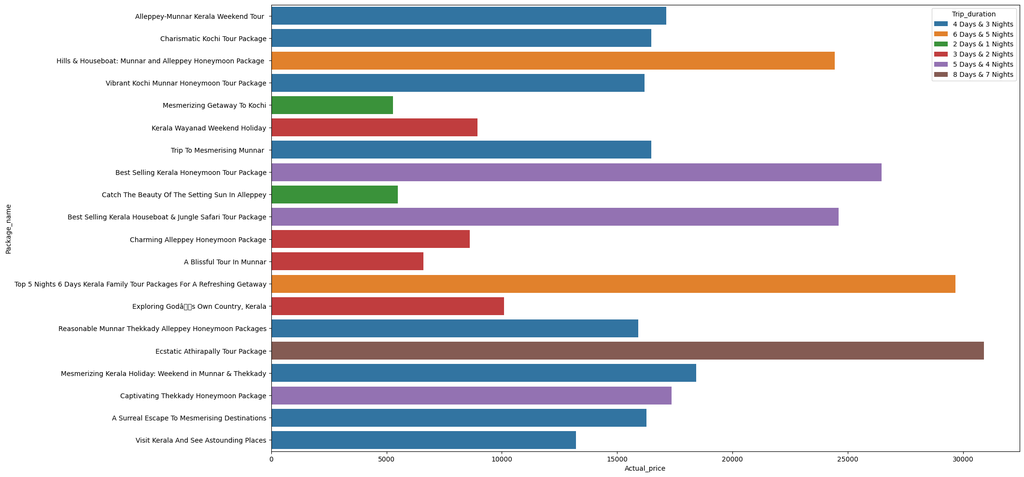

```python
plt.figure(figsize=(20,12))
sns.barplot(data=df,y='Package_name',x='Actual_price',hue='Trip_duration')
#plt.tight_layout()
```

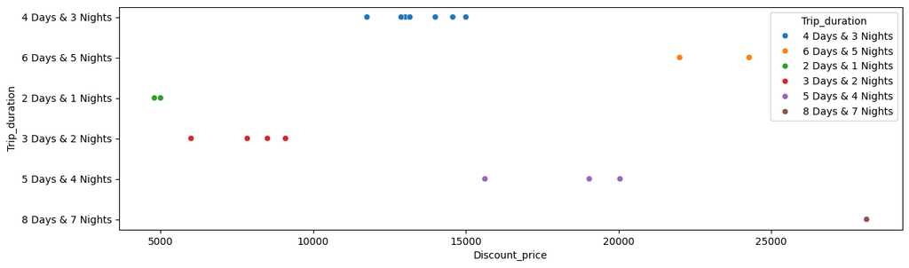

```python
plt.figure(figsize=(14,4))
sns.scatterplot(data=df,x='Discount_price',y='Trip_duration',hue='Trip_duration');
```

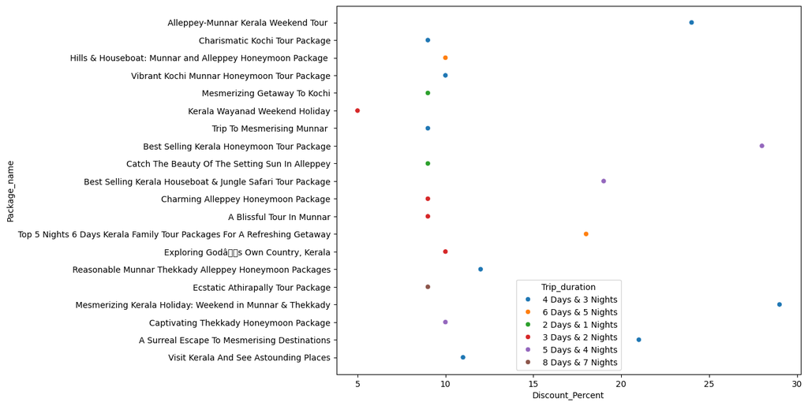

```python
plt.figure(figsize=(10,8))
sns.scatterplot(data=df,x='Discount_Percent',y='Package_name',hue='Trip_duration')
```

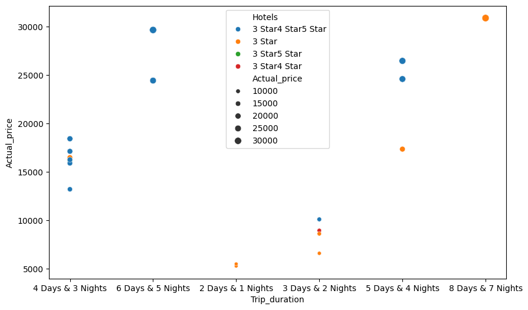

```python
plt.figure(figsize=(10,6))
sns.scatterplot(data=df,
                x='Trip_duration',
                y='Actual_price',
                hue='Hotels',
                size='Actual_price')
```

[output not shown]

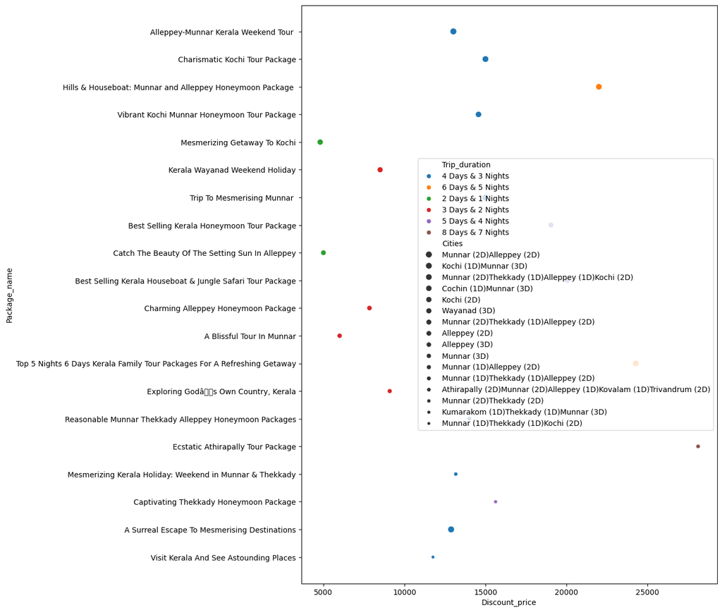

```python
plt.figure(figsize=(10,14))
sns.scatterplot(
    data=df,
    hue='Trip_duration',
    x='Discount_price',
    size='Cities',
    y='Package_name'
)
```

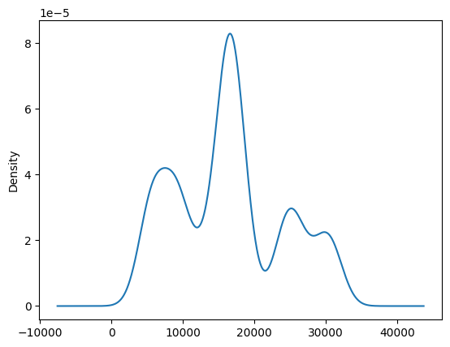

```python
df['Actual_price'].plot(kind='kde')
```

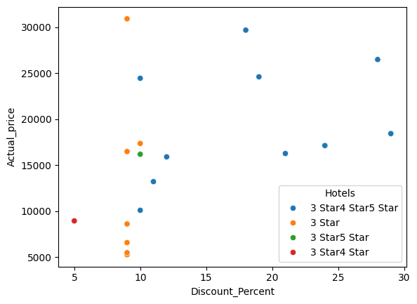

```python
sns.scatterplot(data=df,x='Discount_Percent',y='Actual_price',hue='Hotels')
```

```python
df['Discount_Percent'].skew()
```

```
np.float64(1.115291760500309)
```

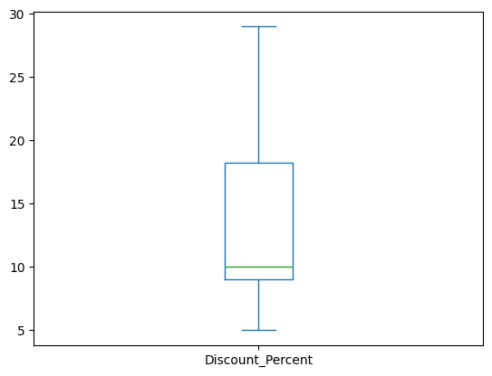

```python
df['Discount_Percent'].plot(kind='box')
```

```python
df['Actual_price'].skew()
```

```
np.float64(0.3070844619572277)
```

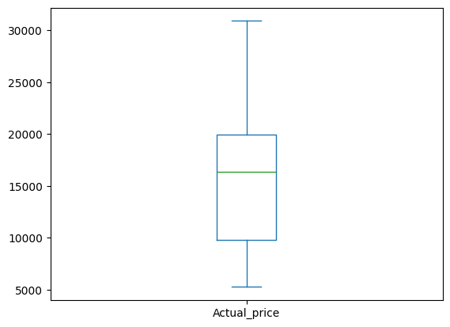

```python
df['Actual_price'].plot(kind='box')
```

```python
df['Discount_price'].skew()
```

```
np.float64(0.47486682572030986)
```

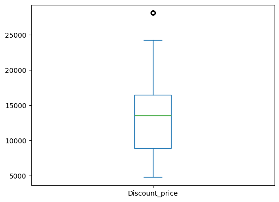

```python
df['Discount_price'].plot(kind='box')
```

```python
df
```

|  | Package_name | Days | Nights | Trip_duration | Discount_Percent | Discount_price | Actual_price | Hotels | Cities | Customizable | Activities_included |
| --- | --- | --- | --- | --- | --- | --- | --- | --- | --- | --- | --- |
| 0 | Alleppey-Munnar Kerala Weekend Tour | 4 | 3 | 4 Days & 3 Nights | 24 | 13020 | 17132 | 3 Star4 Star5 Star | Munnar (2D)Alleppey (2D) | Yes | Spice Plantations Hill station Houseboat Stay ... |
| 1 | Charismatic Kochi Tour Package | 4 | 3 | 4 Days & 3 Nights | 9 | 15000 | 16484 | 3 Star | Kochi (1D)Munnar (3D) | Yes | Waterfalls Adventure Nature Shopping Wildlife ... |
| 2 | Hills & Houseboat: Munnar and Alleppey Honeymo... | 6 | 5 | 6 Days & 5 Nights | 10 | 22000 | 24444 | 3 Star4 Star5 Star | Munnar (2D)Thekkady (1D)Alleppey (1D)Kochi (2D) | Yes | Periyar Wildlife Sanctuary Cruises Eravikulam ... |
| 3 | Vibrant Kochi Munnar Honeymoon Tour Package | 4 | 3 | 4 Days & 3 Nights | 10 | 14571 | 16190 | 3 Star5 Star | Cochin (1D)Munnar (3D) | Yes | Scenic views Adventure Tea gardens Hill statio... |
| 4 | Mesmerizing Getaway To Kochi | 2 | 1 | 2 Days & 1 Nights | 9 | 4800 | 5275 | 3 Star | Kochi (2D) | Yes | Scenerylandscape Sightseeing Leisure Time Natu... |
| ... | ... | ... | ... | ... | ... | ... | ... | ... | ... | ... | ... |
| 1215 | Ecstatic Athirapally Tour Package | 8 | 7 | 8 Days & 7 Nights | 9 | 28123 | 30904 | 3 Star | Athirapally (2D)Munnar (2D)Alleppey (1D)Kovala... | Yes | Athirapally waterfalls Nature Munnar Hill stat... |
| 1216 | Mesmerizing Kerala Holiday: Weekend in Munnar ... | 4 | 3 | 4 Days & 3 Nights | 29 | 13167 | 18434 | 3 Star4 Star5 Star | Munnar (2D)Thekkady (2D) | Yes | Hills Adventure Jungle Safari Nature Wildlife ... |
| 1217 | Captivating Thekkady Honeymoon Package | 5 | 4 | 5 Days & 4 Nights | 10 | 15624 | 17360 | 3 Star | Kumarakom (1D)Thekkady (1D)Munnar (3D) | Yes | Ideal for Couples Water Activities Adventure H... |
| 1218 | A Surreal Escape To Mesmerising Destinations | 4 | 3 | 4 Days & 3 Nights | 21 | 12880 | 16269 | 3 Star4 Star5 Star | Munnar (2D)Alleppey (2D) | Yes | Romantic Hill station Hills Cruises Waterfalls... |
| 1219 | Visit Kerala And See Astounding Places | 4 | 3 | 4 Days & 3 Nights | 11 | 11760 | 13213 | 3 Star4 Star5 Star | Munnar (1D)Thekkady (1D)Kochi (2D) | Yes | Natural Beauty Tea Garden Spice Garden Sightse... |

1220 rows × 11 columns

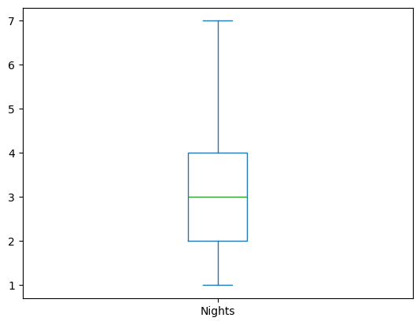

```python
df['Nights'].plot(kind='box')
```

### Multivariate

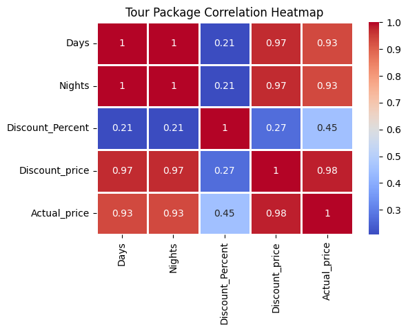

```python
data = df[['Days', 'Nights', 'Discount_Percent','Discount_price', 'Actual_price']]
corr = data.corr()
plt.figure(figsize=(6,4))
sns.heatmap(corr,annot=True,cmap='coolwarm',linewidths=2)
plt.title("Tour Package Correlation Heatmap")
plt.show()
```

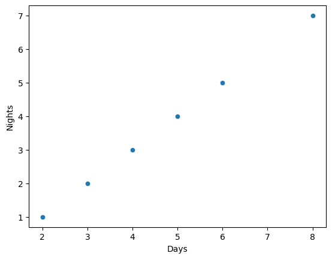

```python
sns.scatterplot(data=df,x='Days',y='Nights') # This plot shows a linear relationship between days and nights, i.e., the correlation coefficient is 1.
```

```python
df['Nights'].corr(df['Days'])
```

```
np.float64(1.0)
```

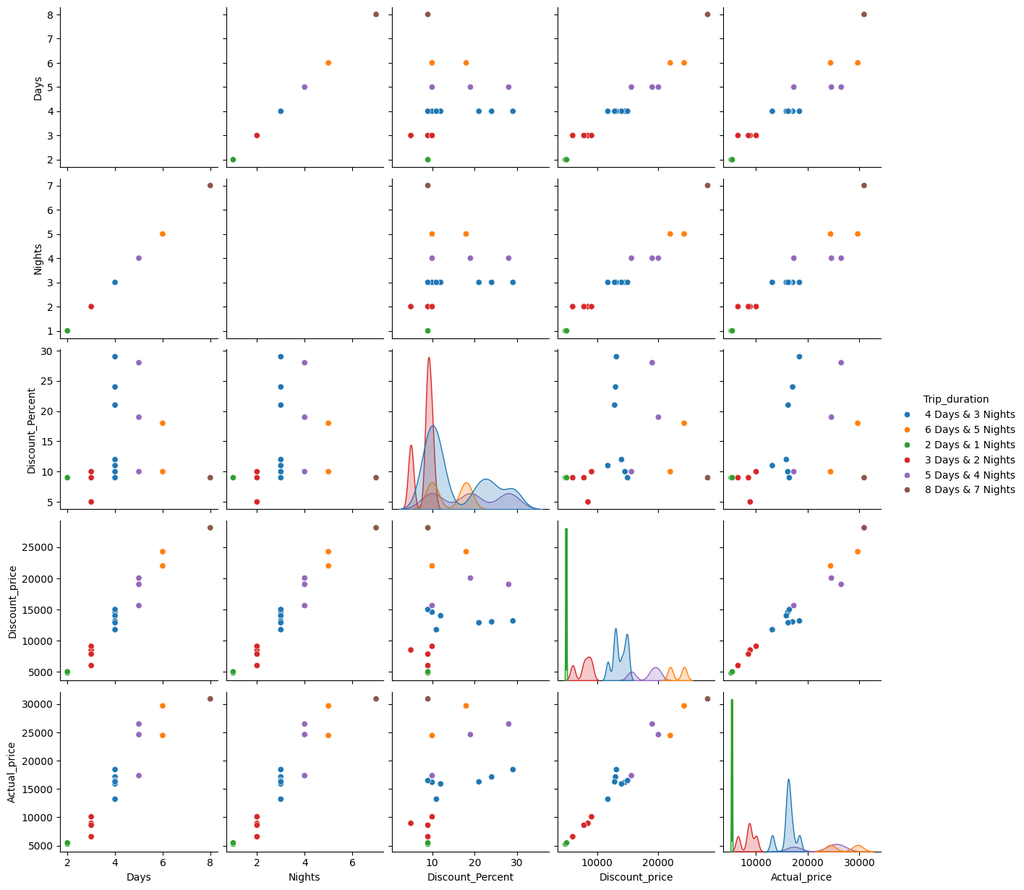

```python
plt.figure(figsize=(20,4))
sns.pairplot(data=df,hue='Trip_duration')
```

The pair plot of numerical variables indicates that some relationships are nearly linear, with correlation coefficients close to 1, such as 0.97.

#### Filter and display the best packages based on parameters like price, trip duration, and cities.

```python
df1=df[(df['Actual_price']<10000)&(df['Days']<7)&(df['Nights']<6)]
```

```python
df1[['Package_name','Days','Nights','Actual_price','Cities','Trip_duration']]
```

|  | Package_name | Days | Nights | Actual_price | Cities | Trip_duration |
| --- | --- | --- | --- | --- | --- | --- |
| 4 | Mesmerizing Getaway To Kochi | 2 | 1 | 5275 | Kochi (2D) | 2 Days & 1 Nights |
| 5 | Kerala Wayanad Weekend Holiday | 3 | 2 | 8947 | Wayanad (3D) | 3 Days & 2 Nights |
| 8 | Catch The Beauty Of The Setting Sun In Alleppey | 2 | 1 | 5495 | Alleppey (2D) | 2 Days & 1 Nights |
| 10 | Charming Alleppey Honeymoon Package | 3 | 2 | 8615 | Alleppey (3D) | 3 Days & 2 Nights |
| 11 | A Blissful Tour In Munnar | 3 | 2 | 6593 | Munnar (3D) | 3 Days & 2 Nights |
| ... | ... | ... | ... | ... | ... | ... |
| 1204 | Mesmerizing Getaway To Kochi | 2 | 1 | 5275 | Kochi (2D) | 2 Days & 1 Nights |
| 1205 | Kerala Wayanad Weekend Holiday | 3 | 2 | 8947 | Wayanad (3D) | 3 Days & 2 Nights |
| 1208 | Catch The Beauty Of The Setting Sun In Alleppey | 2 | 1 | 5495 | Alleppey (2D) | 2 Days & 1 Nights |
| 1210 | Charming Alleppey Honeymoon Package | 3 | 2 | 8615 | Alleppey (3D) | 3 Days & 2 Nights |
| 1211 | A Blissful Tour In Munnar | 3 | 2 | 6593 | Munnar (3D) | 3 Days & 2 Nights |

305 rows × 6 columns

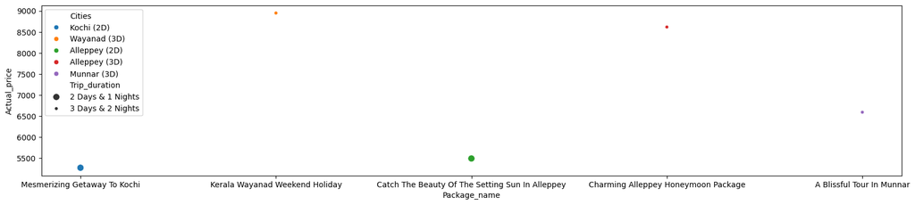

```python
plt.figure(figsize=(20,4))
sns.scatterplot(data=df1,y='Actual_price',x='Package_name',size='Trip_duration',hue='Cities')
```

```python
df2=df[(df['Actual_price']>30000)&(df['Days']==8)&(df['Nights']==7)]
```

```python
df2[['Package_name','Trip_duration','Actual_price','Discount_price','Cities']]
```

|  | Package_name | Trip_duration | Actual_price | Discount_price | Cities |
| --- | --- | --- | --- | --- | --- |
| 15 | Ecstatic Athirapally Tour Package | 8 Days & 7 Nights | 30904 | 28123 | Athirapally (2D)Munnar (2D)Alleppey (1D)Kovala... |
| 35 | Ecstatic Athirapally Tour Package | 8 Days & 7 Nights | 30904 | 28123 | Athirapally (2D)Munnar (2D)Alleppey (1D)Kovala... |
| 55 | Ecstatic Athirapally Tour Package | 8 Days & 7 Nights | 30904 | 28123 | Athirapally (2D)Munnar (2D)Alleppey (1D)Kovala... |
| 75 | Ecstatic Athirapally Tour Package | 8 Days & 7 Nights | 30904 | 28123 | Athirapally (2D)Munnar (2D)Alleppey (1D)Kovala... |
| 95 | Ecstatic Athirapally Tour Package | 8 Days & 7 Nights | 30904 | 28123 | Athirapally (2D)Munnar (2D)Alleppey (1D)Kovala... |
| ... | ... | ... | ... | ... | ... |
| 1135 | Ecstatic Athirapally Tour Package | 8 Days & 7 Nights | 30904 | 28123 | Athirapally (2D)Munnar (2D)Alleppey (1D)Kovala... |
| 1155 | Ecstatic Athirapally Tour Package | 8 Days & 7 Nights | 30904 | 28123 | Athirapally (2D)Munnar (2D)Alleppey (1D)Kovala... |
| 1175 | Ecstatic Athirapally Tour Package | 8 Days & 7 Nights | 30904 | 28123 | Athirapally (2D)Munnar (2D)Alleppey (1D)Kovala... |
| 1195 | Ecstatic Athirapally Tour Package | 8 Days & 7 Nights | 30904 | 28123 | Athirapally (2D)Munnar (2D)Alleppey (1D)Kovala... |
| 1215 | Ecstatic Athirapally Tour Package | 8 Days & 7 Nights | 30904 | 28123 | Athirapally (2D)Munnar (2D)Alleppey (1D)Kovala... |

61 rows × 5 columns

```python
df
```

|  | Package_name | Days | Nights | Trip_duration | Discount_Percent | Discount_price | Actual_price | Hotels | Cities | Customizable | Activities_included |
| --- | --- | --- | --- | --- | --- | --- | --- | --- | --- | --- | --- |
| 0 | Alleppey-Munnar Kerala Weekend Tour | 4 | 3 | 4 Days & 3 Nights | 24 | 13020 | 17132 | 3 Star4 Star5 Star | Munnar (2D)Alleppey (2D) | Yes | Spice Plantations Hill station Houseboat Stay ... |
| 1 | Charismatic Kochi Tour Package | 4 | 3 | 4 Days & 3 Nights | 9 | 15000 | 16484 | 3 Star | Kochi (1D)Munnar (3D) | Yes | Waterfalls Adventure Nature Shopping Wildlife ... |
| 2 | Hills & Houseboat: Munnar and Alleppey Honeymo... | 6 | 5 | 6 Days & 5 Nights | 10 | 22000 | 24444 | 3 Star4 Star5 Star | Munnar (2D)Thekkady (1D)Alleppey (1D)Kochi (2D) | Yes | Periyar Wildlife Sanctuary Cruises Eravikulam ... |
| 3 | Vibrant Kochi Munnar Honeymoon Tour Package | 4 | 3 | 4 Days & 3 Nights | 10 | 14571 | 16190 | 3 Star5 Star | Cochin (1D)Munnar (3D) | Yes | Scenic views Adventure Tea gardens Hill statio... |
| 4 | Mesmerizing Getaway To Kochi | 2 | 1 | 2 Days & 1 Nights | 9 | 4800 | 5275 | 3 Star | Kochi (2D) | Yes | Scenerylandscape Sightseeing Leisure Time Natu... |
| ... | ... | ... | ... | ... | ... | ... | ... | ... | ... | ... | ... |
| 1215 | Ecstatic Athirapally Tour Package | 8 | 7 | 8 Days & 7 Nights | 9 | 28123 | 30904 | 3 Star | Athirapally (2D)Munnar (2D)Alleppey (1D)Kovala... | Yes | Athirapally waterfalls Nature Munnar Hill stat... |
| 1216 | Mesmerizing Kerala Holiday: Weekend in Munnar ... | 4 | 3 | 4 Days & 3 Nights | 29 | 13167 | 18434 | 3 Star4 Star5 Star | Munnar (2D)Thekkady (2D) | Yes | Hills Adventure Jungle Safari Nature Wildlife ... |
| 1217 | Captivating Thekkady Honeymoon Package | 5 | 4 | 5 Days & 4 Nights | 10 | 15624 | 17360 | 3 Star | Kumarakom (1D)Thekkady (1D)Munnar (3D) | Yes | Ideal for Couples Water Activities Adventure H... |
| 1218 | A Surreal Escape To Mesmerising Destinations | 4 | 3 | 4 Days & 3 Nights | 21 | 12880 | 16269 | 3 Star4 Star5 Star | Munnar (2D)Alleppey (2D) | Yes | Romantic Hill station Hills Cruises Waterfalls... |
| 1219 | Visit Kerala And See Astounding Places | 4 | 3 | 4 Days & 3 Nights | 11 | 11760 | 13213 | 3 Star4 Star5 Star | Munnar (1D)Thekkady (1D)Kochi (2D) | Yes | Natural Beauty Tea Garden Spice Garden Sightse... |

1220 rows × 11 columns

```python
df3=df[(df['Discount_Percent']>25)&(df['Discount_price']<14000)&(df['Hotels'].str.contains('5 Star'))&(df['Days']==4)&(df['Nights']==3)]
```

```python
df3[['Package_name','Discount_Percent','Discount_price','Hotels','Trip_duration','Cities']]
```

|  | Package_name | Discount_Percent | Discount_price | Hotels | Trip_duration | Cities |
| --- | --- | --- | --- | --- | --- | --- |
| 16 | Mesmerizing Kerala Holiday: Weekend in Munnar ... | 29 | 13167 | 3 Star4 Star5 Star | 4 Days & 3 Nights | Munnar (2D)Thekkady (2D) |
| 36 | Mesmerizing Kerala Holiday: Weekend in Munnar ... | 29 | 13167 | 3 Star4 Star5 Star | 4 Days & 3 Nights | Munnar (2D)Thekkady (2D) |
| 56 | Mesmerizing Kerala Holiday: Weekend in Munnar ... | 29 | 13167 | 3 Star4 Star5 Star | 4 Days & 3 Nights | Munnar (2D)Thekkady (2D) |
| 76 | Mesmerizing Kerala Holiday: Weekend in Munnar ... | 29 | 13167 | 3 Star4 Star5 Star | 4 Days & 3 Nights | Munnar (2D)Thekkady (2D) |
| 96 | Mesmerizing Kerala Holiday: Weekend in Munnar ... | 29 | 13167 | 3 Star4 Star5 Star | 4 Days & 3 Nights | Munnar (2D)Thekkady (2D) |
| ... | ... | ... | ... | ... | ... | ... |
| 1136 | Mesmerizing Kerala Holiday: Weekend in Munnar ... | 29 | 13167 | 3 Star4 Star5 Star | 4 Days & 3 Nights | Munnar (2D)Thekkady (2D) |
| 1156 | Mesmerizing Kerala Holiday: Weekend in Munnar ... | 29 | 13167 | 3 Star4 Star5 Star | 4 Days & 3 Nights | Munnar (2D)Thekkady (2D) |
| 1176 | Mesmerizing Kerala Holiday: Weekend in Munnar ... | 29 | 13167 | 3 Star4 Star5 Star | 4 Days & 3 Nights | Munnar (2D)Thekkady (2D) |
| 1196 | Mesmerizing Kerala Holiday: Weekend in Munnar ... | 29 | 13167 | 3 Star4 Star5 Star | 4 Days & 3 Nights | Munnar (2D)Thekkady (2D) |
| 1216 | Mesmerizing Kerala Holiday: Weekend in Munnar ... | 29 | 13167 | 3 Star4 Star5 Star | 4 Days & 3 Nights | Munnar (2D)Thekkady (2D) |

61 rows × 6 columns

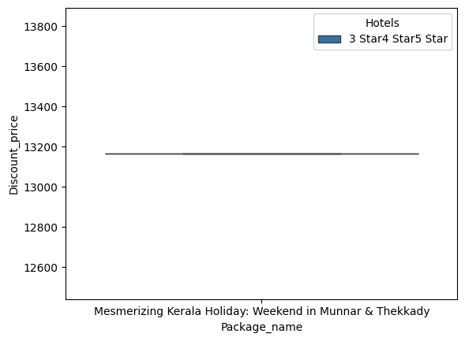

```python
sns.boxplot(data=df3,x='Package_name',y='Discount_price',hue='Hotels');
```

```python
df4=df[df['Actual_price']<10000]
```

```python
df4[['Package_name','Trip_duration','Actual_price','Discount_price','Discount_Percent','Cities','Hotels']]
```

|  | Package_name | Trip_duration | Actual_price | Discount_price | Discount_Percent | Cities | Hotels |
| --- | --- | --- | --- | --- | --- | --- | --- |
| 4 | Mesmerizing Getaway To Kochi | 2 Days & 1 Nights | 5275 | 4800 | 9 | Kochi (2D) | 3 Star |
| 5 | Kerala Wayanad Weekend Holiday | 3 Days & 2 Nights | 8947 | 8500 | 5 | Wayanad (3D) | 3 Star4 Star |
| 8 | Catch The Beauty Of The Setting Sun In Alleppey | 2 Days & 1 Nights | 5495 | 5000 | 9 | Alleppey (2D) | 3 Star |
| 10 | Charming Alleppey Honeymoon Package | 3 Days & 2 Nights | 8615 | 7840 | 9 | Alleppey (3D) | 3 Star |
| 11 | A Blissful Tour In Munnar | 3 Days & 2 Nights | 6593 | 6000 | 9 | Munnar (3D) | 3 Star |
| ... | ... | ... | ... | ... | ... | ... | ... |
| 1204 | Mesmerizing Getaway To Kochi | 2 Days & 1 Nights | 5275 | 4800 | 9 | Kochi (2D) | 3 Star |
| 1205 | Kerala Wayanad Weekend Holiday | 3 Days & 2 Nights | 8947 | 8500 | 5 | Wayanad (3D) | 3 Star4 Star |
| 1208 | Catch The Beauty Of The Setting Sun In Alleppey | 2 Days & 1 Nights | 5495 | 5000 | 9 | Alleppey (2D) | 3 Star |
| 1210 | Charming Alleppey Honeymoon Package | 3 Days & 2 Nights | 8615 | 7840 | 9 | Alleppey (3D) | 3 Star |
| 1211 | A Blissful Tour In Munnar | 3 Days & 2 Nights | 6593 | 6000 | 9 | Munnar (3D) | 3 Star |

305 rows × 7 columns

```python
df4.sample(10)
```

|  | Package_name | Days | Nights | Trip_duration | Discount_Percent | Discount_price | Actual_price | Hotels | Cities | Customizable | Activities_included |
| --- | --- | --- | --- | --- | --- | --- | --- | --- | --- | --- | --- |
| 885 | Kerala Wayanad Weekend Holiday | 3 | 2 | 3 Days & 2 Nights | 5 | 8500 | 8947 | 3 Star4 Star | Wayanad (3D) | Yes | Nature Waterfall Hills Weekend Getaway Hill st... |
| 824 | Mesmerizing Getaway To Kochi | 2 | 1 | 2 Days & 1 Nights | 9 | 4800 | 5275 | 3 Star | Kochi (2D) | Yes | Scenerylandscape Sightseeing Leisure Time Natu... |
| 725 | Kerala Wayanad Weekend Holiday | 3 | 2 | 3 Days & 2 Nights | 5 | 8500 | 8947 | 3 Star4 Star | Wayanad (3D) | Yes | Nature Waterfall Hills Weekend Getaway Hill st... |
| 848 | Catch The Beauty Of The Setting Sun In Alleppey | 2 | 1 | 2 Days & 1 Nights | 9 | 5000 | 5495 | 3 Star | Alleppey (2D) | Yes | Cruise along Adventure Leisure Day Cruises Hou... |
| 944 | Mesmerizing Getaway To Kochi | 2 | 1 | 2 Days & 1 Nights | 9 | 4800 | 5275 | 3 Star | Kochi (2D) | Yes | Scenerylandscape Sightseeing Leisure Time Natu... |
| 765 | Kerala Wayanad Weekend Holiday | 3 | 2 | 3 Days & 2 Nights | 5 | 8500 | 8947 | 3 Star4 Star | Wayanad (3D) | Yes | Nature Waterfall Hills Weekend Getaway Hill st... |
| 1088 | Catch The Beauty Of The Setting Sun In Alleppey | 2 | 1 | 2 Days & 1 Nights | 9 | 5000 | 5495 | 3 Star | Alleppey (2D) | Yes | Cruise along Adventure Leisure Day Cruises Hou... |
| 984 | Mesmerizing Getaway To Kochi | 2 | 1 | 2 Days & 1 Nights | 9 | 4800 | 5275 | 3 Star | Kochi (2D) | Yes | Scenerylandscape Sightseeing Leisure Time Natu... |
| 268 | Catch The Beauty Of The Setting Sun In Alleppey | 2 | 1 | 2 Days & 1 Nights | 9 | 5000 | 5495 | 3 Star | Alleppey (2D) | Yes | Cruise along Adventure Leisure Day Cruises Hou... |
| 524 | Mesmerizing Getaway To Kochi | 2 | 1 | 2 Days & 1 Nights | 9 | 4800 | 5275 | 3 Star | Kochi (2D) | Yes | Scenerylandscape Sightseeing Leisure Time Natu... |

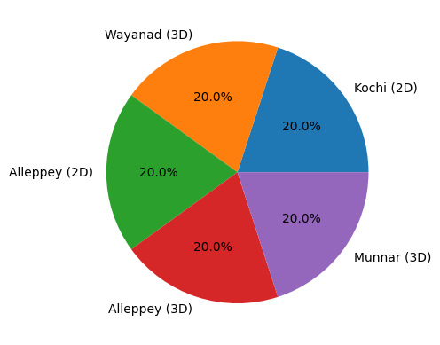

```python
df4['Cities'].value_counts().plot(kind='pie',autopct='%1.1f%%')
```

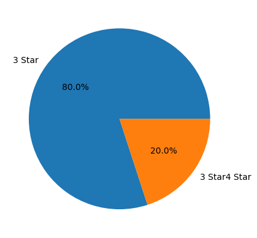

```python
df4['Hotels'].value_counts().plot(kind='pie',autopct='%1.1f%%')
```

Under a budget of 10,000, mostly 3-star hotels are provided.

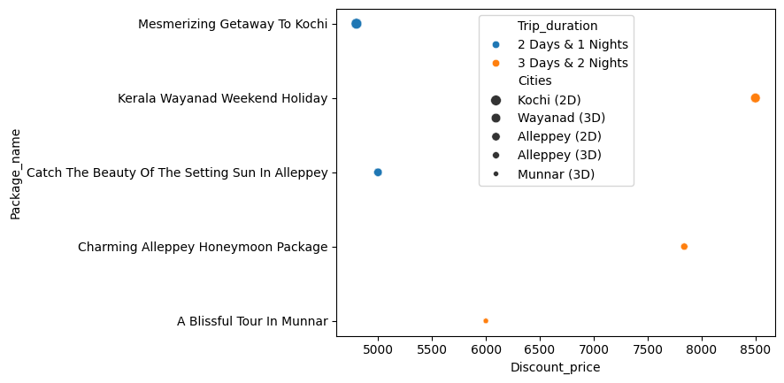

```python
sns.scatterplot(data=df4,x='Discount_price',y='Package_name',hue='Trip_duration',size='Cities');
```

```python
df5=df[(df['Actual_price']>10000)&(df['Actual_price']<20000)]
```

```python
df5[['Package_name','Trip_duration','Actual_price','Discount_price','Discount_Percent','Cities','Hotels']]
```

|  | Package_name | Trip_duration | Actual_price | Discount_price | Discount_Percent | Cities | Hotels |
| --- | --- | --- | --- | --- | --- | --- | --- |
| 0 | Alleppey-Munnar Kerala Weekend Tour | 4 Days & 3 Nights | 17132 | 13020 | 24 | Munnar (2D)Alleppey (2D) | 3 Star4 Star5 Star |
| 1 | Charismatic Kochi Tour Package | 4 Days & 3 Nights | 16484 | 15000 | 9 | Kochi (1D)Munnar (3D) | 3 Star |
| 3 | Vibrant Kochi Munnar Honeymoon Tour Package | 4 Days & 3 Nights | 16190 | 14571 | 10 | Cochin (1D)Munnar (3D) | 3 Star5 Star |
| 6 | Trip To Mesmerising Munnar | 4 Days & 3 Nights | 16484 | 15000 | 9 | Munnar (2D)Alleppey (2D) | 3 Star |
| 13 | Exploring Godâs Own Country, Kerala | 3 Days & 2 Nights | 10102 | 9092 | 10 | Munnar (1D)Alleppey (2D) | 3 Star4 Star5 Star |
| ... | ... | ... | ... | ... | ... | ... | ... |
| 1214 | Reasonable Munnar Thekkady Alleppey Honeymoon ... | 4 Days & 3 Nights | 15909 | 14000 | 12 | Munnar (1D)Thekkady (1D)Alleppey (2D) | 3 Star4 Star5 Star |
| 1216 | Mesmerizing Kerala Holiday: Weekend in Munnar ... | 4 Days & 3 Nights | 18434 | 13167 | 29 | Munnar (2D)Thekkady (2D) | 3 Star4 Star5 Star |
| 1217 | Captivating Thekkady Honeymoon Package | 5 Days & 4 Nights | 17360 | 15624 | 10 | Kumarakom (1D)Thekkady (1D)Munnar (3D) | 3 Star |
| 1218 | A Surreal Escape To Mesmerising Destinations | 4 Days & 3 Nights | 16269 | 12880 | 21 | Munnar (2D)Alleppey (2D) | 3 Star4 Star5 Star |
| 1219 | Visit Kerala And See Astounding Places | 4 Days & 3 Nights | 13213 | 11760 | 11 | Munnar (1D)Thekkady (1D)Kochi (2D) | 3 Star4 Star5 Star |

610 rows × 7 columns